# PA1_template

```r
## Seems to be at 8:35am!
```

Okay, now that we’ve gotten a general sense of how the data presents itself, let’s move on to something more serious. It seems like there are a lot of missing values in the dataset.

```r
table(!complete.cases(data))  ## the TRUEs will be incomplete cases...
```

```
##
## FALSE  TRUE
## 15264  2304
```

```r
## Even the first day of the dataset doesn't seem to have recorded any steps taken by our subject...

head(data)
```

```
##   steps       date interval
## 1    NA 2012-10-01        0
## 2    NA 2012-10-01        5
## 3    NA 2012-10-01       10
## 4    NA 2012-10-01       15
## 5    NA 2012-10-01       20
## 6    NA 2012-10-01       25
```

We can use a simple imputation strategy to help us try to mitigate potential bias from these missing cases. To keep things simple, let’s just replace missing values with the average for that variable.

```r
data[is.na(data$steps) == "TRUE", 1] <- mean(data$steps, na.rm = T)

table(!complete.cases(data)) ## Looks like all the NAs have been filled in!
```

```
##
## FALSE
## 17568
```

To follow up, let’s see if if/how the overall distribution has changed after imputing the missing values. We’ll use the same code as the first section.

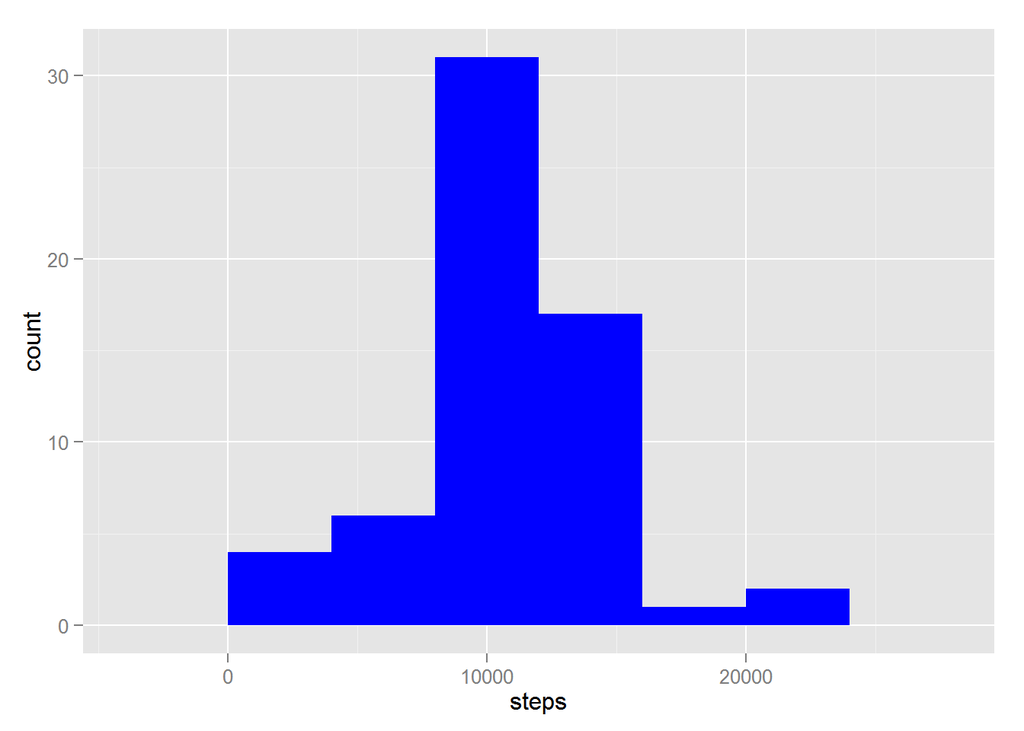

```r
dailystepstotal <- aggregate(steps ~ date, data, sum)

plot <- ggplot(dailystepstotal, aes(steps))
plot + geom_histogram(binwidth = 4000, fill = "blue")
```

```r
mean(dailystepstotal$steps)
```

```
## [1] 10766
```

```r
median(dailystepstotal$steps)
```

```
## [1] 10766
```

Alright, now the last thing we might look at is how a person’s activity might change based on the given day of the week. Granted, our sample population is based off a single subject, but there’s two hypotheses we might test. Are people more active and mobile during the week because they have more to do (and thus spend less time moving during the weekend)? Or are people mostly stationary during weekdays as they focus on their given tasks, and then use their free time to be more active on weekends?

Let’s start by splitting the dates into “weekdays” and “weekends”.

```r
daytype <- weekdays(data$date)

data <- cbind(data, daytype)

table(grepl("Saturday", data$daytype))
```

```
##
## FALSE  TRUE
## 15264  2304
```

```r
table(grepl("Sunday", data$daytype))
```

```
##
## FALSE  TRUE
## 15264  2304
```

```r
data$daytype <- as.character(data$daytype)

for (i in 1:nrow(data)) {
    if (data$daytype[i] == "Saturday" | data$daytype[i] == "Sunday") {
        data$daytype[i] <- "Weekend"
    } else {
        data$daytype[i] <- "Weekday"
    }
}

data$daytype <- factor(data$daytype, levels = c("Weekday", "Weekend"),
                       labels = c("Weekday", "Weekend"))
```

Cool, now we have our grouping variable! Now let’s just build a plot where we compare steps on weekdays vs weekends. We’ll keep using the imputed data, but this time we won’t push hard on correcting the interval labels. We know it’s measured on a 24-hour clock, and we’re just interested in seeing the overall differences in pattern.

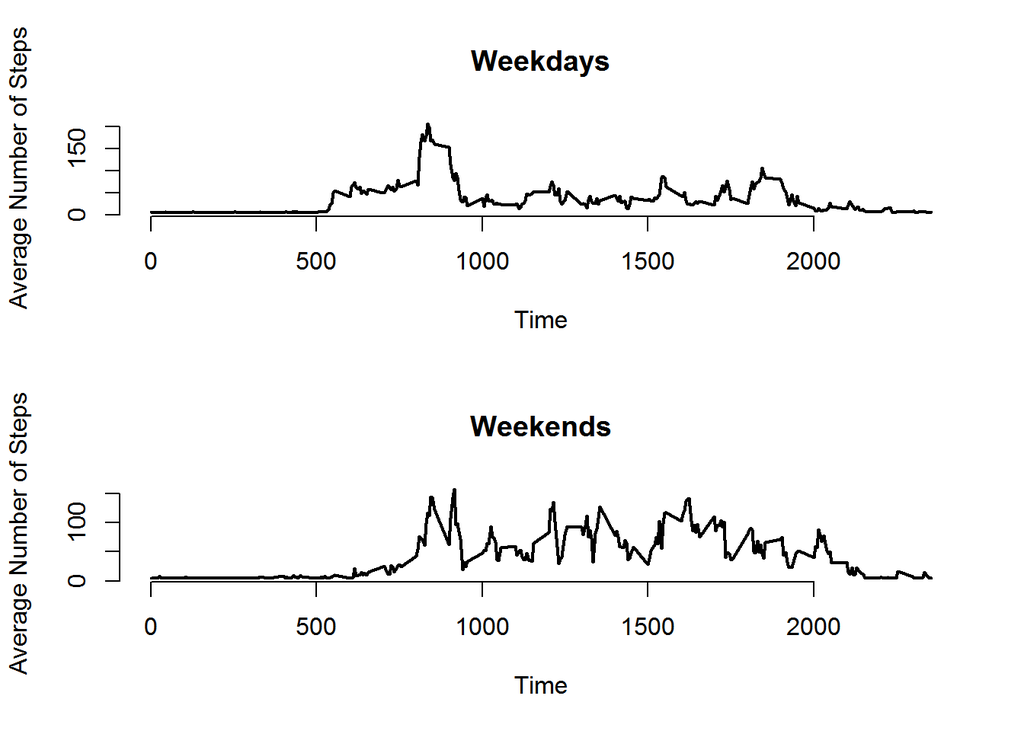

```r
## Making our subsets
weekdays <- data[data$daytype == "Weekday",]
weekends <- data[data$daytype == "Weekend",]

weekdaystepavg <- aggregate(steps ~ interval, weekdays, mean)
weekendstepavg <- aggregate(steps ~ interval, weekends, mean)

par(mfrow = c(2, 1))

with(weekdaystepavg, plot(interval, steps, type = "l", xlab = "Time",
                ylab = "Average Number of Steps", main = "Weekdays",
                frame.plot = FALSE, lwd = 2))

with(weekendstepavg, plot(interval, steps, type = "l", xlab = "Time",
                ylab = "Average Number of Steps", main = "Weekends",
                frame.plot = FALSE, lwd = 2))
```

It seems that the extremes in terms of walking activiy aren’t as large on the weekends, but there’s definitely more variability. This seems very reasonable; we have more consistent routines during the week, but we may be more or less active on the weekends depending on how we choose to spend our time.